# Trust in political institutions and support for authoritarianism in Latin American students: Does civic knowledge make a difference?

Daniel Miranda, Juan Carlos Castillo, Catalina Miranda & José Daniel Conejeros.

Borrador: 04/09/2020

Abstract

Trust in political institutions represents a central component of democratic systems. When citizens lack confidence in state bodies as the government and the parliament, the legitimacy of democracy is dangerously challenged. In the case of Latin America we observe a critical scenario, with a steady decrease of institutional trust in the last decade, accompanied by alarming levels of support for authoritarian regimes. Most of the evidence in this regards refers to adult population, leaving sidelined the young generations who certainly have a stake in the future of democracy in the region. Focusing on the role of the acquisition of civic knowledge at school as a protecting factor of democracy, this research analyzes the role of civic knowledge to understand trust in civic institutions and authoritarian attitudes in eighth-grade students. The data corresponds to the International Civic and Citizenship Education Study (ICCS) 2009 and 2016, in which seven Latin American Countries have participated. The results indicates a puzzling role of civic knowledge, as it diminishes trust in institutions but at the same time reduces authoritarian beliefs, in a similar way in the Latin American countries across time. The consequences for democracy and citizenship education are addressed in the conclusion.

# Introducción

La literatura especializada plantea que la confianza institucional es un aspecto central tanto del funcionamiento de las democracias como de su legitimidad (Lipset, 1959; Uslaner, 2018; Zmerli & Meer, 2017). Esto es particularmente relevante en la región de América Latina, que muestra uno de los menores niveles de confianza a nivel mundial (Catterberg & Moreno, 2006). Parte de las explicaciones de esta baja confianza es que las instituciones en América Latina se han desarrollado entre la presencia de gobiernos autoritarios e intentos de consolidación democrática, así como también altos índices de corrupción (Bargsted, Somma, & Castillo, 2017). Este escenario genera una serie de interrogantes acerca de las condiciones de la legitimidad de la democracia en America Latina, entre ellas ¿Estamos experimentando una crisis de apoyo a la democracia?¿Existe un riesgo de apoyar a gobiernos autoritarios? ¿En qué medida las nuevas generaciones estarían dispuestas a apoyar una dictadura y/o deslegitimar de las instituciones políticas?

En la educación para la ciudadanía se depositan las mayores expectativas respecto de la promoción de los valores democráticos y la disminución de aquellas que pueden atentar contra la democracia misma. En ese sentido el conocimiento político adquirido podría jugar un rol muy importante a este respecto.

Uno de los aspectos centrales a tomar en cuenta al momento de evaluar tanto la confianza en las instituciones como las actitudes autoritarias es el rol que puede jugar el conocimiento político como antecedente. En un sentido ideal, el conocimiento cívico-político es considerado como *la madre* la confianza (Galston, 2001, 2007). Dado que parte relevante del conocimiento respecto de temas políticos se transmite intencionadamente a nivel escolar, resulta de especial relevancia conocer en qué medida el conocimiento adquirido en edad juvenil se asocia o no a la confianza en instituciones.

En estudios internacionales que evalúan conocimiento político, los países de América Latina tienden a obtener niveles más bajos de conocimiento que países desarrollados (Schulz, Ainley, Cox, & Friedman, 2018). Adicionalmente, se ha observado el rol que juega el conocimiento cívico-político sobre una serie de aspectos como: confianza institucional, diferentes tipos de participación, tolerancia, creencias autoritarias entre otras (Castillo, Miranda, Bonhomme, Cox, & Bascopé, 2014; Miranda, Castillo, & Cumsille, 2018; Sandoval-Hernandez, Miranda, Treviño, & Schmelkes, 2019). Sin embargo, aún queda pendiente profundizar sobre la heterogeneidad con que este factor puede influir sobre la confianza o si este puede condicionar otros resultados, así como también sobre en que medida estas asociaciones ya son posibles de pesquisar (y eventualmente modificar) en la etapa escolar. Así, se abre la interrogante sobre el rol que puede jugar el conocimiento cívico adquirido en la escuela para comprender no solo los niveles de confianza que los jóvenes depositan sobre las instituciones, sino también sobre el apoyo a creencias autoritarias en América Latina.

# Confianza institucional

La confianza institucional posee una vasta agenda de investigación en ciencias sociales (ver Zmerli & Meer (2017)), y en general se entiende como una evaluación que se hace sobre una institución cívico-política (van der Meer & Hakhverdian, 2016). Para Offe (1999) esta evaluación se basa en la expectativa acerca de funcionamiento de esta (Offe, 1999; Segovia, Haye, González, Manzi, & Carvacho, 2008). Adicionalmente, Hardin (2001) propone que dicha evaluación se produce de manera situada en un contexto particular. Así, la confianza en las instituciones políticas como el parlamento o partidos políticos puede ser entendido como la evaluación que los ciudadanos hacen del funcionamiento que estas tienen en un contexto dado.

Los niveles de confianza institucional puede variar de acuerdo a una serie de características tanto contextuales como individuales. En el primer grupo se consideran aspectos como la performance económica, la distribución de la riqueza o el cambio político (Citrin & Stoker, 2018; Martini & Quaranta, 2020). Para el caso del nivel individual se consideran diversas variables como aspectos genéticos, de personalidad, la eficacia percibida de las instituciones políticas y sociales (Torney-Purta, Richardson, & Barber, 2004), la conciencia de corruptibilidad (Carrasco, Banerjee, Treviño, & Villalobos, 2019) y/o la efectividad percibida de la institución (Lauglo, 2013). También, se ha vinculado con las características socio-económicas. Aquí destaca el nivel educacional, desde el cuál se propone que a mayor educación los ciudadanos cuentan con mayor información, apoyan en mayor medidas valores democráticos y adquieren mayores habilidades para evaluar el funcionamiento de las instituciones (Lipset, 1960; van der Meer & Hakhverdian, 2016).

Dado que el contexto en que se produce el desarrollo de confianza institucional es relevante para la formación de estas actitudes, se hace importante destacar las particularidades del desarrollo institucional en América Latina. En los países de la región el desarrollo de las instituciones democráticas ha sufrido una serie de contradicciones, marcado por una alternancia entre autoritarismo, democracia y semi-democracias (Bargsted et al., 2017). Esto se traduce en una deslegitimación histórica y progresiva de las instituciones, consistente con los bajos niveles de confianza observados en la región (Latinobarometro, 2018).

## Autoritarismo

Las dictaduras pasadas y actuales en América Latina le heredan a la región el reconocimiento tener cierta tendencia al autoritarismo. A pesar que hoy en su mayoría los países pueden ser considerados democráticos, en la última década se han presentado una serie de eventos que erosionan la confianza política. Por un lado, la región se caracteriza por democracias interrumpidas e inestabilidad política a lo largo del siglo SXX y lo que va del SXXI, con la permanente amenaza del autoritarismo. Sin ir más lejos, en la última década se observan crisis democráticas importantes como en Venezuela, Brasil, Perú, Bolivia o Chile, sólo por mencionar las más evidentes. En estos países se ha observado el cierre de medios de comunicación, el cierre del parlamento, cuestionamientos a los procesos eleccionarios, violación de Derechos Humanos, entre otros.

Consistentemente se observa que una alta proporción de ciudadanos considera que “in some circumstances an authoritarian government is preferable than a democratic one” (15%) o que “people like one do not care about a democratic government than an authoritarian one” (28%). Ambas opciones poco democráticas suman que un 43% de personas en America Latina no apoyan de manera decidida la democracia como mejor forma de Gobierno (Latinobarometro, 2018). En población juvenil, un estudio de (Schulz et al., 2018) examina en dos períodos de tiempo (ICCS 2009 e ICCS 2016) el apoyo de los estudiantes de 8vo básico a gobiernos con prácticas autoritarias en cinco países de América Latina, mostrando que aunque la mayoría de los jóvenes rechaza las prácticas autoritarias, una proporción importante está dispuesta a apoyarlas (Schulz et al., 2018). En ese sentido el nivel de apoyo a prácticas autoritarias o a este tipo de gobiernos puede ser considerado como parte de la cultura política en América Latina (Almond & Verba, 1989).

La adherencia a prácticas autoritarias se conecta fácilmente con el autoritarismo de derecha. Este concepto, ampliamente utilizado en la psicología social, consiste básicamente en una orientación ideológica a apoyar la autoridad fuerte y castigar la desviación normativa (Altemeyer, 1981). Luego de varias versiones (Ver Duckitt, 2015) se proponen tres dimensiones centrales: sumisión autoritaria, que describe el grado de sumisión hacia la autoridad establecida; agresión autoritaria, que se entiende como una actitud agresiva en contra de grupos o personas sancionados por la autoridad (percepción); y, convencionalismo, que describe el grado de adherencia a convenciones, tradiciones y normas sociales (Altemeyer, 1996; Funke, 2005).

Desde sus primero estudios, el autoritarismo es visto como una amenaza importante a la democracia (Dewey, 1989), lo que puede verse acentuado en una región como America Latina. En ese sentido, los países han hecho diversos esfuerzos para expandir los ideales democráticos a travez de la formación ciudadana desde el sistema escolar (Cox & Castillo, 2015). En ese sentido, una mejor educación ciudadana debería llevar a menor disponibilidad de ideas autoritarias (Schulz et al., 2018).

## El rol del conocimiento cívico.

El conocimiento cívico puede ser definido como la capacidad (proficiency) de conocimiento acerca de diversos dominios como: sistemas cívico-sociales, principios cívicos, procedimientos de partición e identidades cívicas(Schulz et al., 2018). Dicha definición presenta grandes similitudes con dos conceptos ampliamente utilizados en la literatura politológica: *conocimiento político*, referido a la información que los ciudadanos manejan acerca del sistema político, y *sofisticación política*, una aproximación más compleja a la expertise sobre temas políticos (Rapeli, 2013). Más allá de las especificidades conceptuales, en todos reconocen el rol que juega este tipo de conocimiento para comprender mejor diversas actitudes y comportamientos relevantes en el marco democrático (Rapeli, 2013).

En cuanto al vínculo con las instituciones cívico-políticas y autoritarismo literatura previa plantea que aquellos con mayores niveles de conocimiento presentarán un mayor apego a la vida pública (Galston, 2001, 2007). Esto implicaría que en general a mayores niveles de conocimiento cívico mayores niveles de confianza institucional. La literatura muestra sistemáticamente que las personas con mayores niveles de conocimiento cívico tienden a involucrarse políticamente de manera diferente que aquellos con menores niveles de conocimiento (Rapeli, 2013). Por ejemplo, desarrollan mayores niveles de tolerancia política (Miranda et al., 2018), presentan mayores niveles de participación política (Castillo et al., 2014; Castillo, Miranda, Bonhomme, Cox, & Bascopé, 2015), presentan menores niveles de autoritarismo (Sandoval-Hernandez et al., 2019). Así, es esperable que los niveles de conocimiento cívico se asocien con una mayor confianza institucional (H1) y menores niveles de auotirtarismo (H2). Sin embargo, estudios comparados en población juvenil muestran evidencia mixta para H1. A partir del estudio CIVED 1999, ICCS 2019 e ICCS 2016 es posible observar que en países desarrollados con bajos índices de corrupción la asociación es positiva, mientras que en países con menor desarrollo y baja alta corrupción la asociación es negativa (Sandoval-Hernandez et al., 2019; Torney-Purta et al., 2004). Para el caso de los países de América Latina la interpretación que predomina es que los jóvenes con alto conocimiento desconfían o son más escépticos, desarrollando en un sentido de crítica hacia las instituciones.

# Metodología:

## a. Data

Los datos analizados en esta investigación corresponden al International Civic and Citizenship Education Study (ICCS) para 6 países de América Latina en su versión 2009 y 5 países para el 2016. Este estudio está a cargo de la Asociación Internacional para la Evaluación del logro educativo (IEA) y ha sido aplicada en tres momentos en el tiempo: CIVED 1999; ICCS 2009 e ICCS 2016. Su propósito es investigar la manera en que los los sistemas educativos preparan a los jóvenes para asumir sus roles como ciudadanos. Los resultados de ICCS han contribuido en el debate acerca de impartir educación cívica y ciudadana en escuelas alrededor de todo el mundo.

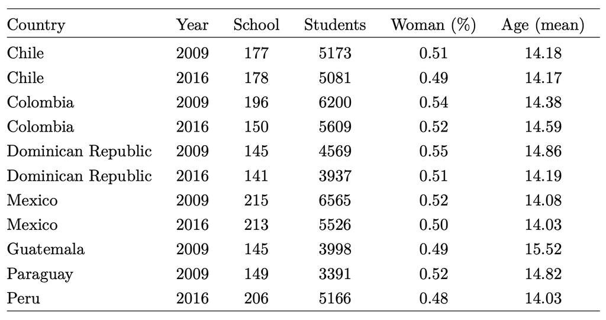

El International Civic and Citizenship Education Study (ICCS) se basa en una prueba internacional de conocimiento cívico que evalúan el conocimiento, capacidad de análisis y razonamiento cívico y ciudadano de los estudiantes. A su vez, también contempla un cuestionario que mide percepciones, actitudes y antecedentes de los estudiantes sobre temas relativos a la ciudadanía, participación en la escuela, clima escolar, entre otras variables. Por último, considera una serie de instrumentos para capturar información de maestros, escuelas y sistemas educativos (Schulz et al., 2011).

## b. Variables

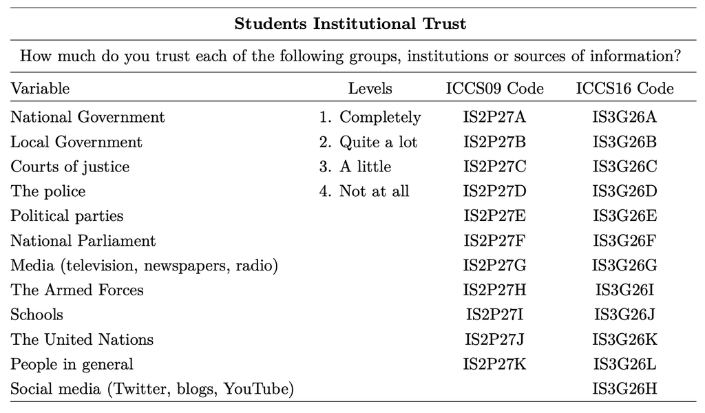

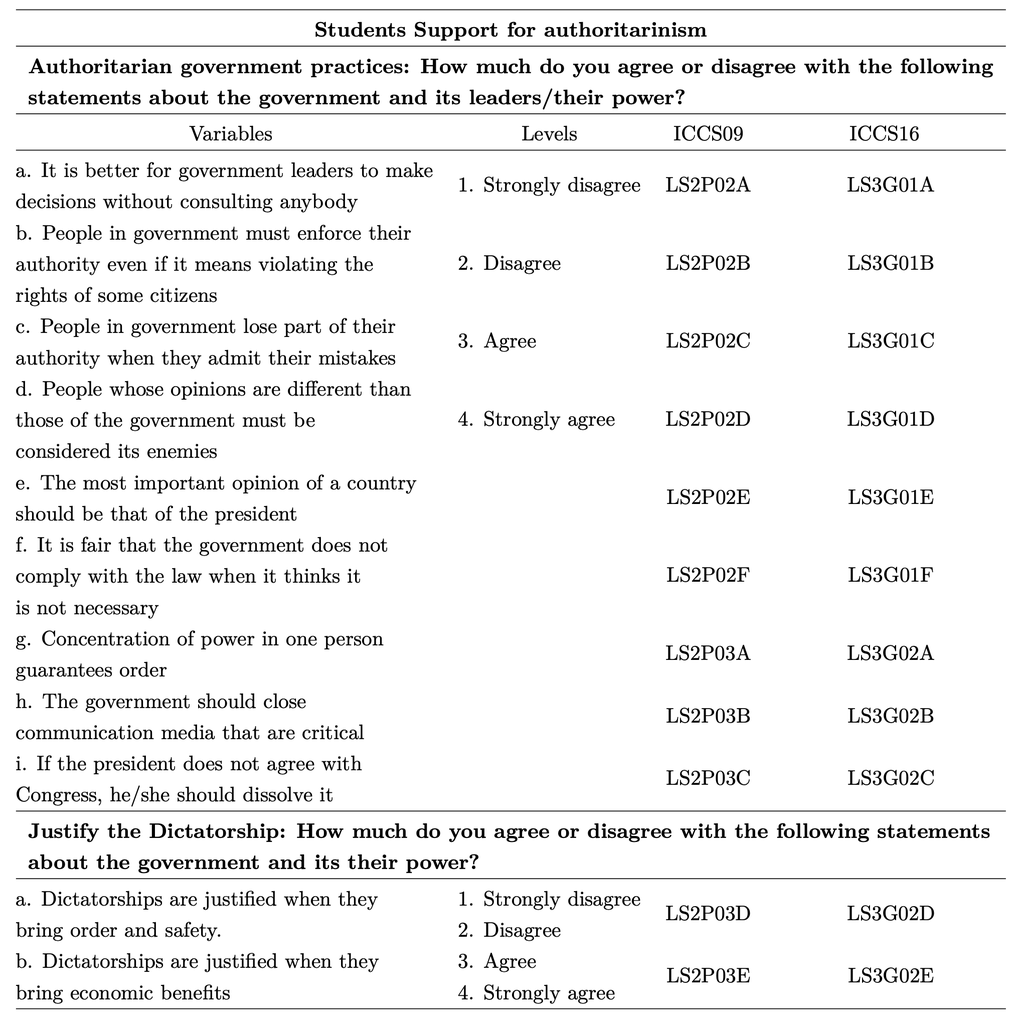

Como principal variableindependiente se utiliza el puntaje de conocimiento alcanzado en la prueba internacional ICCS.

La prueba de conocimiento cívico consiste en un set de 79 ítemes que se aplican organizados en siete formatos distintos, en que cada estudiante responde un cuadernillo que contiene tres subgrupos de preguntas. Para estimar el nivel de conocimiento cívico en función de este diseño, se utiliza un modelo de Ítem Response Theory (IRT) para estimar cinco valores plausibles como puntaje. Esta variable presenta un promedio internacional de 500 puntos y una desviación estándar de 100. A continuación se resumen los puntajes para cada uno de los países en el año 2009 y 2016:

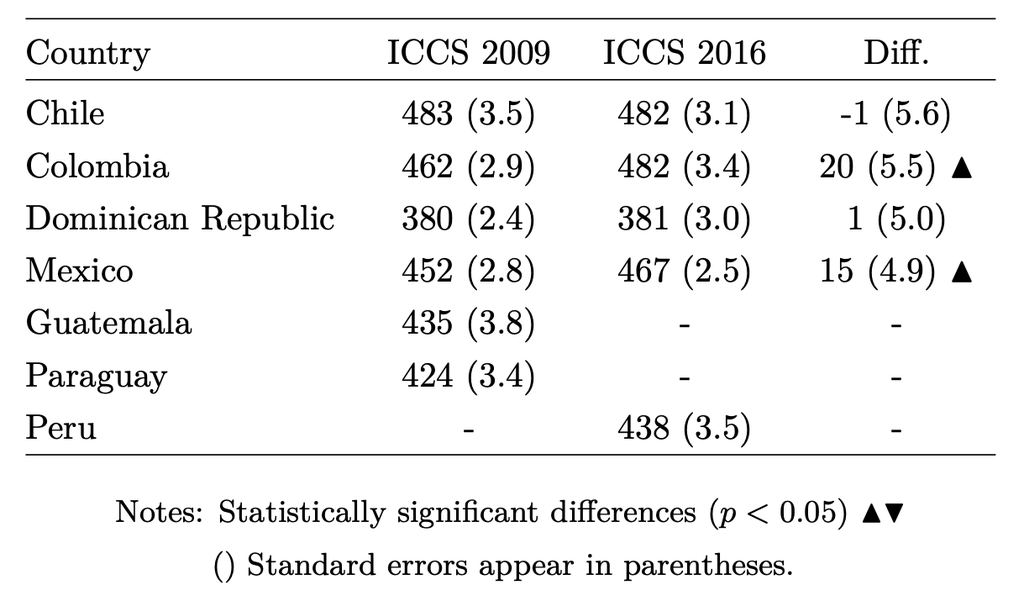

El resto de las variables independientes cumplen el objetivo de controlar la asociación estadística entre el apoyo a autoritarismos, confianza en instituciones políticas y conocimiento cívico. En ese sentido, se utiliza un *proxy* para evaluar el origen socio-económico del estudiante y el capital cultural. Para la primera dimensión se utiliza una medida estandarizada que captura el mayor nivel educacional alcanzado por el padre o la madre, para la segunda dimensión se utiliza el número de libros en el hogar. A esto se agregar un indicador que identifica el género del estudiante y un indicador del nivel de discusión política que realiza el estudiante con amigos y familia fuera de la sala de clases.

## c. Analytical Strategy

A nivel descriptivo se evalúan las diferencias estadísticas para cada uno de los indicadores de confianza institucional entre los años 2009 y 2016. Luego se utilizan dos indicadores que resumen la información de confianza en instituciones políticas y apoyo a prácticas autoritarias (ambos construidos mediante un análisis factorial confirmatorio). Finalmente, se estiman modelos de regresión OLS a nivel agregado para evaluar la asociación entre conocimiento cívico y los indicadores descritos, utilizando los controles estadísticos mencionados en el apartado anterior.

# Results

## a. Descriptive trends across time of institutional trust

Tercero, se observan niveles medios de confianza interpersonal. En 2009 los jóvenes declaran confiar en las personas entre un 47% (Guatemala y México) y un 57%(Paraguay), mientras que en 2016 entre un 43% (Colombia) y un 52%(México). Aunque América Latina es reconocida como una región del mundo que presenta mucha desconfianza interpersonal en población adulta (Latinobarometro, 2018), llama la atención que en población escolar de 8vo grado esta desconfianza no es tan extrema.

Finalmente, respecto del cambio o estabilidad de la confianza entre 2009 y 2016, se observa cierta diversidad entre países. Por un lado, República Dominicana y México tienden a mantenerse estables o incluso a incrementarse los niveles de confianza para la mayoría de las instituciones evaluadas. Llama la atención que en México la confianza en las FF AA y las cortes de justicia hayan aumentado un 9% y un 12% respectivamente. Por otro lado, Chile y Colombia muestran una tendencia general a la baja en la confianza en la mayoría de las instituciones evaluadas. En Chile caen significativamente la confianza en el Gobierno central, Gobiernos locales, las Cortes de Justicia, la Policía, el Parlamento y la confianza en las personas; mientras que en Colombia caen significativamente la confianza en el Gobierno central, los Partidos Políticos y la confianza en las personas.

## b. Descriptive trends across time of support for authoritarian practices

[figure not shown]

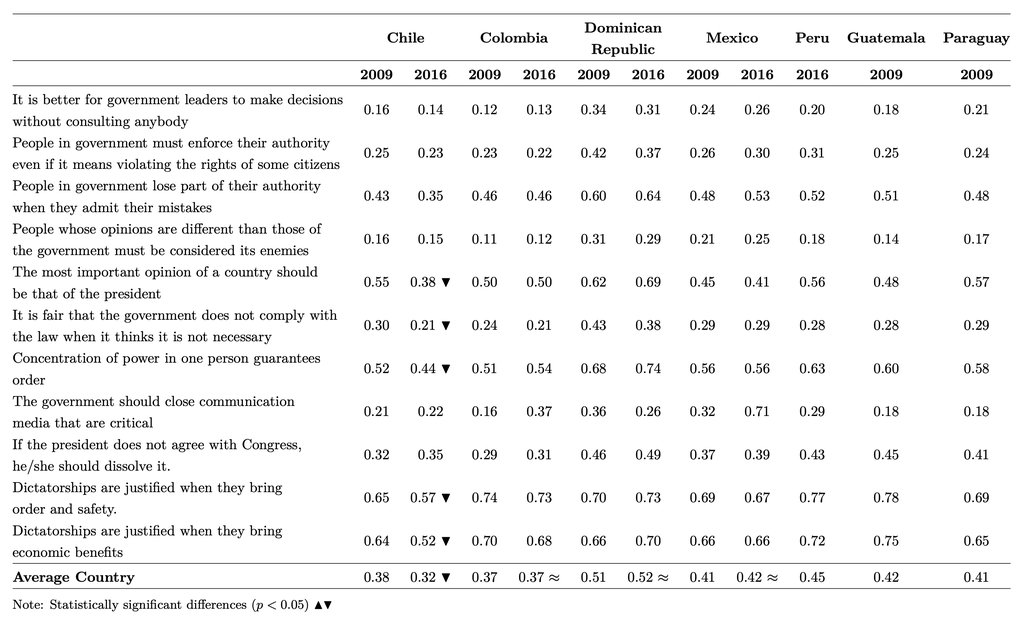

## c. Association of institutional trust, support authoritarianism and civic knowledge

Respecto del rol que juega el conocimiento cívico sobre el apoyo a prácticas autoritarias y sobre los niveles de confianza, descriptivamente se puede observar que a mayores niveles de conocimiento cívico disminuyen los niveles de apoyo a prácticas autoritarias; pero también disminuyen los niveles de confianza (Ver figuras 1 y 2). Jóvenes que entienden mejor los aspectos conceptuales del sistema político tienden a desvalidar las prácticas autoritarias de los gobiernos, pues al parecer entienden mejor que ese tipo de prácticas son inconsistentes con la vida democrática. Sin embargo, esos mismos jóvenes mejor preparados en conocimiento cívico confían menos en las instituciones que conforman el sistema político. Adicionalmente, es posible observar que aquellos que apoyan en mayor medida prácticas autoritarias, tienden a confiar más en instituciones cívico-políticas que aquellos menor apoyo autoritario (ver figura 1), lo que resulta un poco contraintuitivo a la luz de supuestos teóricos presentados anteriormente.

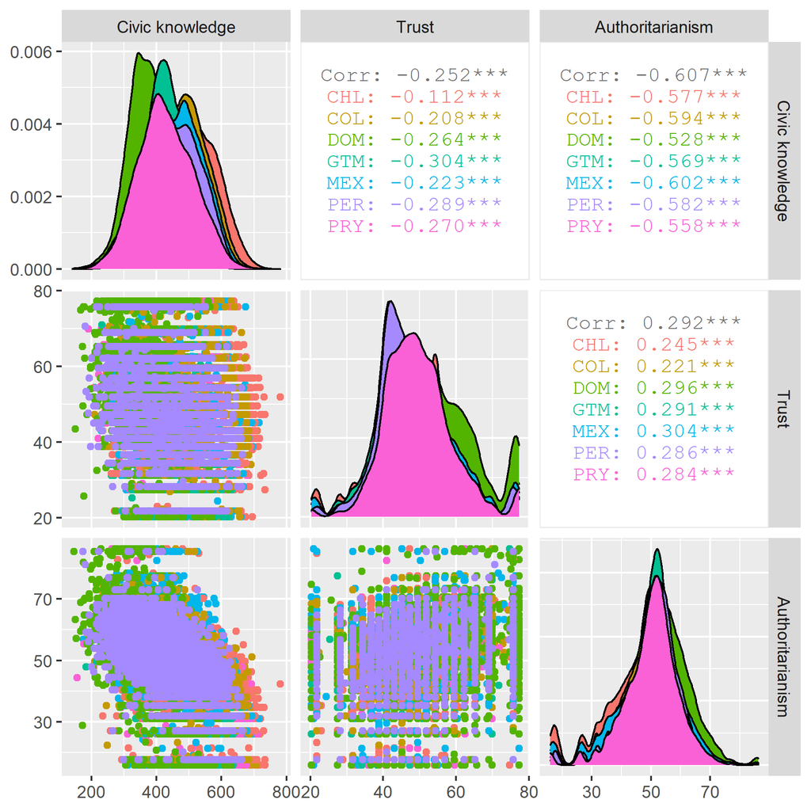

Trust in civic institutions, Support for authoritarianism and Civic knowledge

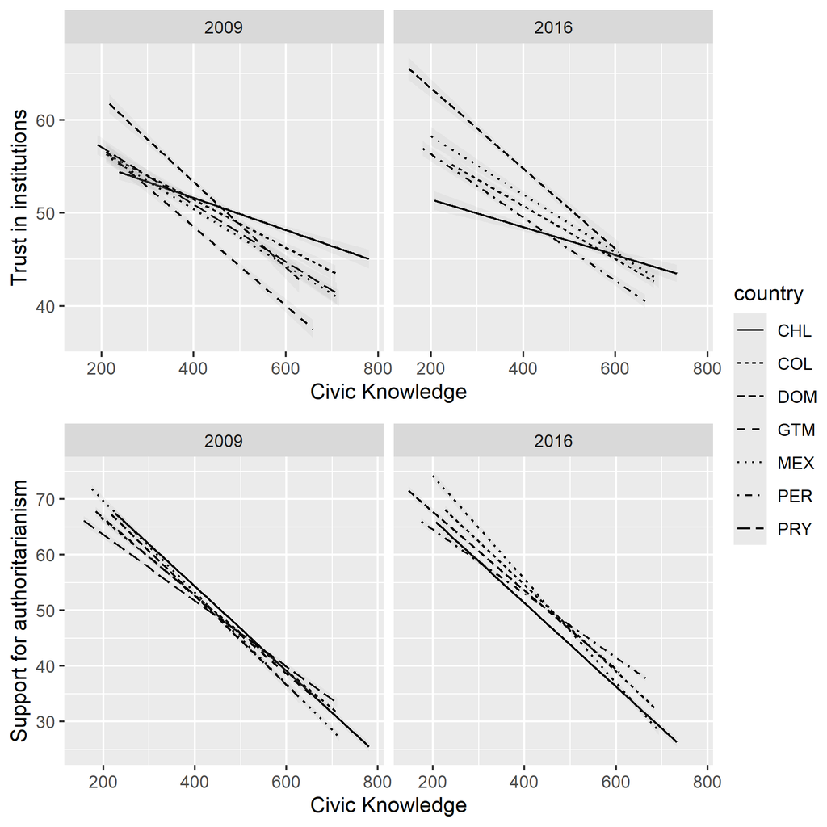

Trust in civic institutions and Civic Knowledge in students

# Discussion and conclussion

Respecto de la confianza institucional aparecen algunos resultados relevantes de comentar. Primero, se observan en general mayores niveles de confianza que en población adulta. Esto lleva preguntarse si ¿son estas generaciones más confiadas que los adultos actuales? o si ¿sucede algo durante el trascurso hacia la vida adulta que disminuye las confianzas?. Segundo, se observan ciertas consistencias con la población adulta. Esto es principalmente que las instituciones políticas son las peor evaluadas. En ese sentido es posible preguntarse si algo de la confianza de los jóvenes tienen sus raíces en los niveles de confianza de los adultos cuidadores. O dicho de otro modo, ¿en qué medida se produce una socialización intergerenacional de la confianza institucional?. Y tercero, se observa que Chile y Colombia muestra bajan relevantes en varias instituciones, mientras que México y República dominicana se mantienen y hasta aumentan en muy pocas instituciones. Esto genera la pregunta acerca de ¿cuales podrían ser los factores macro que pueden dar cuenta de los cambios temporales de los países?

Respecto de la pregunta central del capítulo, ¿cuál es el rol del conocimiento cívico para explicar los niveles de confianza institucional y los niveles de autoritarismo en jóvenes de America Latina? Siguiendo los resultados observados, es posible afirmar tener mayores niveles de conocimiento cívico tiene un efecto paradójico. Por un lado, y contrario al supuesto politológico, impacta negativamente sobre los niveles de confianza. Saber más, hace más críticos a los jóvenes. Al parecer, el carácter desarrollo institucional irregular, interrumpido y hasta fallido debe ser considerado al momento de pensar las hipótesis. Por otro lado, alineado con las expectativas, mayor conocimiento lleva a menores niveles de autoritarismo. El conocimiento cívico puede funcionar como una especie de inoculación ante la influencia de ideas anti-democráticas como son las prácticas autoritarias presentadas a los estudiantes participantes del estudio ICCS 2009 y 2016. Visto así, el conocimiento cívico disminuye las disponibilidad de ideas autoritarias, pero promueve o posibilita la desconfianza en las instituciones. En ese sentido, la típica demanda de los sistemas escolares por mayor formación ciudadana (entendida ampliamente por mayor entrega de conocimientos) no lograría resolver todos los males. El problema es más complejo y su solución también. Entonces ¿cómo la formación ciudadana mejoraría el compromiso cívico?¿cómo el sistema escolar se hace cargo de la formación cudadana en contextos de desarrollo institicional irregular/fallido?

Un resultado que llama la atención es que jóvenes con mayores niveles autoritarismo tienden a evaluar más positivamente las instituciones. Este resultado contraintuitivo requiere ser observado con mayor profundidad. Por otro lado, el apoyo a las prácticas autoritarias podría ser vinculado fácilmente con el continuo izquierda derecha. En esa asociación, las personas de derecha tienden a presentar mayores niveles de autoritarismo y las personas de izquierda menos. Entonces, es posible pensar que la posición política también esta jugando un rol sobre la evaluación que estos hacen de las instituciones. Estas posibles relaciones no son despejadas aquí, por tanto queda abierta la pregunta sobre el comportamiento que tendrían las actitudes autoritarias al momento evaluación institucional en contextos de alto y bajo conocimiento.

[^2]

# References

Almond, G. A., & Verba, S. (1989). *The Civic Culture: Political Attitudes and Democracy in Five Nations*. SAGE.

Altemeyer, B. (1996). *The Authoritarian Specter* (Edición: y First edition). Cambridge, Mass: Harvard University Press.

Bargsted, M., Somma, N., & Castillo, J. C. (2017). Dynamics of Political Trust in Latin AmericaDynamics of Political Trust in Latin America. In *Handbook on Political Trust* (Zmerli & van der Meer). Cheltenham, UK ; Northampton, MA: Edward Elgar Pub.

Carrasco, D., Banerjee, R., Treviño, E., & Villalobos, C. (2019). Civic knowledge and open classroom discussion: Explaining tolerance of corruption among 8th-grade students in Latin America. *Educational Psychology*.

Castillo, J. C., Miranda, D., Bonhomme, M., Cox, C., & Bascopé, M. (2014). Social inequality and changes in students’ expected political participation in Chile. *Education, Citizenship and Social Justice*, *9*(2), 140–156.

Castillo, J. C., Miranda, D., Bonhomme, M., Cox, C., & Bascopé, M. (2015). Mitigating the political participation gap from the school: The roles of civic knowledge and classroom climate. *Journal of Youth Studies*, *18*(1), 16–35.

Catterberg, G., & Moreno, A. (2006). The individual bases of political trust: Trends in new and established democracies. *International Journal of Public Opinion Research*, *18*(1), 31–48.

Citrin, J., & Stoker, L. (2018). Political Trust in a Cynical Age. *Annual Review of Political Science*, *21*(1), 49–70. https://doi.org/10.1146/annurev-polisci-050316-092550

Cox, C., & Castillo, J. C. (Eds.). (2015). *Aprendizaje de la ciudadanía: Contextos, experiencias y resultados* (First). Ediciones UC.

Dewey, J. (1989). *Freedom and Culture*. New York: Prometheus.

Federico, C. M., Fisher, E. L., & Deason, G. (2011). Expertise and the Ideological Consequences of the Authoritarian Predisposition. *Public Opinion Quarterly*, *75*(4), 686–708. https://doi.org/10.1093/poq/nfr026

Funke, F. (2005). The Dimensionality of Right-Wing Authoritarianism: Lessons from the Dilemma between Theory and Measurement. *Political Psychology*, *26*(2), 195–218. https://doi.org/10.1111/j.1467-9221.2005.00415.x

Galston, W. A. (2001). Political Knowledge, Political Engagement, and Civic Education. *Annual Review of Political Science*, *4*(1), 217–234. https://doi.org/10.1146/annurev.polisci.4.1.217

Galston, W. A. (2007). Civic Knowledge, Civic Education, and Civic Engagement: A Summary of Recent Research. *International Journal of Public Administration*, *30*(6-7), 623–642. https://doi.org/10.1080/01900690701215888

Jedinger, A., & Burger, A. M. (2019). The role of right-wing authoritarianism and political sophistication in shaping attitudes toward redistribution. *European Journal of Social Psychology*, *49*(3), 560–573. https://doi.org/10.1002/ejsp.2524

Latinobarometro. (2018). *Informe 2018*. Corporación Latinobarometro.

Lauglo, J. (2013). Do more knowledgeable adolescents have more rationally based civic attitudes? Analysis of 38 countries. *Educational Psychology*, *33*(3), 262–282. https://doi.org/10.1080/01443410.2013.772773

Lipset, S. M. (1959). Some Social Requisites of Democracy: Economic Development and Political Legitimacy. *The American Political Science Review*, *53*(1), 69–105. https://doi.org/10.2307/1951731

Lipset, S. M. (1960). *Political man: The social bases of politics*. Doubleday.

Martini, S., & Quaranta, M. (2020). Political Support in Flux. In S. Martini & M. Quaranta (Eds.), *Citizens and Democracy in Europe: Contexts, Changes and Political Support* (pp. 1–20). https://doi.org/10.1007/978-3-030-21633-7_1

Miranda, D., Castillo, J. C., & Cumsille, P. (2018). The Political Socialization of Attitudes Toward Equal Rights from a Comparative Perspective. In *IEA Research for Education*. *Teaching Tolerance in a Globalized World* (pp. 103–123). https://doi.org/10.1007/978-3-319-78692-6_7

Offe, C. (1999). How can we trust our fellow citizens? In M. E. Warren (Ed.), *Democracy and Trust* (pp. 42–87). https://doi.org/10.1017/CBO9780511659959.003

Rapeli, L. (2013). *The Conception of Citizen Knowledge in Democratic Theory*. Springer.

Sandoval-Hernandez, A., Miranda, D., Treviño, E., & Schmelkes, S. (2019). *Is Democracy Overrated? Latin American Students’ Support for Dictatorships. IEA Compass: Briefs in Education. Number 7*. International Association for the Evaluation of Educational Achievement.

Schulz, W., Ainley, J., Cox, C., & Friedman, T. (2018). *Young People’s Views of Government, Peaceful Coexistence, and Diversity in Five Latin American Countries: IEA International Civic and Citizenship Education Study 2016 Latin American Report*. https://doi.org/10.1007/978-3-319-95393-9

Schulz, W., Ainley, J., & Fraillon, J. (2011). ICCS 2009 Technical Report. *International Association for the Evaluation of Educational Achievement*.

Segovia, C., Haye, A., González, R., Manzi, J., & Carvacho, H. (2008). Confianza en instituciones políticas en Chile: Un modelo de los componentes centrales de juicios de confianza. *Revista de Ciencia Política (Santiago)*, *28*(2), 39–60. https://doi.org/10.4067/S0718-090X2008000200002

Torney-Purta, J., Richardson, W. K., & Barber, C. H. (2004). Trust in Government-Related Institutions and Civic Engagement among Adolescents: Analysis of Five Countries from the IEA Civic Education Study. CIRCLE Working Paper 17. *Center for Information and Research on Civic Learning and Engagement*.

Uslaner, E. M. (2018). *The Oxford Handbook of Social and Political Trust*. Oxford University Press.

van der Meer, T., & Hakhverdian, A. (2016). Political Trust as the Evaluation of Process and Performance: A Cross-National Study of 42 European Countries: *Political Studies*. https://doi.org/10.1177/0032321715607514

Zaller, J. R. (1992). *The Nature and Origins of Mass Opinion*. https://doi.org/10.1017/CBO9780511818691

Zmerli, S., & Meer, T. W. G. V. der. (2017). *Handbook on Political Trust*. Cheltenham, UK ; Northampton, MA: Edward Elgar Publishing Ltd.

[^1]: República Dominicana presenta niveles mucho mayores de confianza respecto de los otros países, aunque siguiendo las mismas tendencias entre instituciones. Para mostrar el patrón mayoritario se excluye este país de los ejemplos presentados
[^2]: Para futuras referencias: Por un lado, como lo anticipa Altemeyer, la valoración de la autoridad tiende a mostrar un correlato con aquellas instituciones que representan también a la autoridad. Adicionalmente, el conocimiento cívico juega un rol relevante sobre la consistencia entre actitudes y comportamiento político (Zaller, 1992). Es decir, este conocimiento puede condicionar la fuerza de la relación entre actitudes políticas y comportamiento. En la misma línea, evidencia previa muestra que personas con mayores niveles de conocimiento muestran mayor asociación entre autoritarismo y conservadurismo (Federico, Fisher, & Deason, 2011), e incluso se invierte la relación entre autoritarismo y actitudes hacia la redistribución de ingresos (Jedinger & Burger, 2019).